# 重賞レース予測レポート【レース終了】

作成日時: 2026/03/22 16:18:40

☞ [マニュアル(pdf)](https://ryutoro-galois.github.io/keiba-predictor/manual/manual.pdf)

☞ 過去6年の同一レース結果: [2025年](https://ryutoro-galois.github.io/keiba-predictor/report/PredResult_2025y_raceDate_20250322_20250323.html), [2024年](https://ryutoro-galois.github.io/keiba-predictor/report/PredResult_2024y_raceDate_20240316_20240317.html), [2023年](https://ryutoro-galois.github.io/keiba-predictor/report/PredResult_2023y_raceDate_20230318_20230319.html), [2022年](https://ryutoro-galois.github.io/keiba-predictor/report/PredResult_2022y_raceDate_20220319_20220321.html), [2021年](https://ryutoro-galois.github.io/keiba-predictor/report/PredResult_2021y_raceDate_20210320_20210321.html), [2020年](https://ryutoro-galois.github.io/keiba-predictor/report/PredResult_2020y_raceDate_20200320_20200322.html)

☞ 過去4週間の別レース結果: [1週前(3/14-15)](https://ryutoro-galois.github.io/keiba-predictor/report/PredResult_2026y_raceDate_20260314_20260315.html), [2週前(3/7-8)](https://ryutoro-galois.github.io/keiba-predictor/report/PredResult_2026y_raceDate_20260307_20260308.html), [3週前(2/28-3/1)](https://ryutoro-galois.github.io/keiba-predictor/report/PredResult_2026y_raceDate_20260228_20260301.html), [4週前(2/21-22)](https://ryutoro-galois.github.io/keiba-predictor/report/PredResult_2026y_raceDate_20260221_20260222.html)

☞ netkeiba: [フラワーカップ(GⅢ)](https://race.netkeiba.com/race/result.html?race_id=202606020711&rf=race_submenu), [ファルコンステークス(GⅢ)](https://race.netkeiba.com/race/result.html?race_id=202607010311&rf=race_submenu), [阪神大賞典(GⅡ)](https://race.netkeiba.com/race/result.html?race_id=202609011011&rf=race_submenu), [愛知杯(GⅢ)](https://race.netkeiba.com/race/result.html?race_id=202607010411&rf=race_submenu)

☞ レース結果(csv): [3/21-22](https://ryutoro-galois.github.io/keiba-predictor/csv/race_result_20260321_20260322.csv)

## 【レース結果(1)】人気と着順の関係

### 【フラワーカップ(2026/03/21(土))】

【フラワーカップ(GⅢ)】  
2026/03/21(土), 06_中山, 芝右1800m

[interactive chart not shown]

### 【ファルコンステークス(2026/03/21(土))】

【ファルコンステークス(GⅢ)】  
2026/03/21(土), 07_中京, 芝左1400m

[interactive chart not shown]

### 【阪神大賞典(2026/03/22(日))】

【阪神大賞典(GⅡ)】  
2026/03/22(日), 09_阪神, 芝右3000m

[interactive chart not shown]

### 【愛知杯(2026/03/22(日))】

[interactive chart not shown]

## 【レース結果(2)】コーナー通過順位

### 【フラワーカップ(2026/03/21(土))】

【フラワーカップ(GⅢ)】  
2026/03/21(土), 06_中山, 芝右1800m

[interactive chart not shown]

### 【ファルコンステークス(2026/03/21(土))】

【ファルコンステークス(GⅢ)】  
2026/03/21(土), 07_中京, 芝左1400m

[interactive chart not shown]

### 【阪神大賞典(2026/03/22(日))】

【阪神大賞典(GⅡ)】  
2026/03/22(日), 09_阪神, 芝右3000m

[interactive chart not shown]

### 【愛知杯(2026/03/22(日))】

[interactive chart not shown]

## 0. 推し馬予測 (AI予測)

### 【フラワーカップ(GⅢ) 2026/03/21(土)】

- 本命(◎): 1-3着内確率(勝負強さ)が1位の馬
- 対抗(◯): 1-3着内確率が2-N位(20%程度以上)の中で予測タイムが最も速い馬
- 3番手(▲): 1-3着内確率が2-N位(20%程度以上)のでダークホース確率が最も高い馬
- 穴: ダークホース確率が上位1-M位(40%程度以上)の中で1-3着内確率が最も高い馬

| 推し馬 | 枠番 | 馬番 | 人気 | オッズ | 馬名 | 騎手 | 調教師 | 予測タイム(sec) | 1_順位 | 1-3着内確率(%) | 2_順位 | ﾀﾞｰｸﾎｰｽ確率(%) | 3_順位 |
| --- | --- | --- | --- | --- | --- | --- | --- | --- | --- | --- | --- | --- | --- |
| 本命(◎) | 2 | 3 | 2 | 3.9 | ゴディアーモ | 津村明秀 | 森一誠 | 111.3 | 6 | 55.7 | 1 | 0.4 | 15 |
| 対抗(◯) | 4 | 8 | 1 | 2.7 | イクシード | Ｃ．ルメール | 木村哲也 | 107.0 | 1 | 33.1 | 4 | 0.4 | 14 |
| 3番手(▲) | 3 | 5 | 7 | 19.0 | クリスレジーナ | 鮫島克駿 | 高野友和 | 111.5 | 7 | 33.7 | 3 | 1.3 | 9 |
| 穴 | 2 | 4 | 16 | 402.8 | ヒルデグリム | 柴田大知 | 小野次郎 | 111.0 | 2 | 14.7 | 8 | 50.9 | 1 |

### 【ファルコンステークス(GⅢ) 2026/03/21(土)】

- 本命(◎): 1-3着内確率(勝負強さ)が1位の馬
- 対抗(◯): 1-3着内確率が2-N位(20%程度以上)の中で予測タイムが最も速い馬
- 3番手(▲): 1-3着内確率が2-N位(20%程度以上)のでダークホース確率が最も高い馬
- 穴: ダークホース確率が上位1-M位(40%程度以上)の中で1-3着内確率が最も高い馬

| 推し馬 | 枠番 | 馬番 | 人気 | オッズ | 馬名 | 騎手 | 調教師 | 予測タイム(sec) | 1_順位 | 1-3着内確率(%) | 2_順位 | ﾀﾞｰｸﾎｰｽ確率(%) | 3_順位 |
| --- | --- | --- | --- | --- | --- | --- | --- | --- | --- | --- | --- | --- | --- |
| 本命(◎) | 6 | 11 | 2 | 9.0 | タガノアラリア | 斎藤新 | 西園翔太 | 79.8 | 5 | 39.0 | 1 | 0.4 | 16.5 |
| 対抗(◯) | 8 | 17 | 5 | 16.2 | タマモイカロス | 小沢大仁 | 藤岡健一 | 79.8 | 7 | 23.0 | 3 | 0.9 | 12.0 |
| 3番手(▲) | 4 | 7 | 4 | 12.6 | フクチャンショウ | 横山武史 | 加藤征弘 | 79.8 | 6 | 28.7 | 2 | 0.9 | 13.0 |
| 穴 | 3 | 5 | 15 | 97.4 | アスミル | 太宰啓介 | 本田優 | 79.5 | 3 | 8.8 | 11 | 47.3 | 1.0 |

### 【阪神大賞典(GⅡ) 2026/03/22(日)】

- 本命(◎): 1-3着内確率(勝負強さ)が1位の馬
- 対抗(◯): 1-3着内確率が2-N位(20%程度以上)の中で予測タイムが最も速い馬
- 3番手(▲): 1-3着内確率が2-N位(20%程度以上)のでダークホース確率が最も高い馬
- 穴: ダークホース確率が上位1-M位(40%程度以上)の中で1-3着内確率が最も高い馬

| 推し馬 | 枠番 | 馬番 | 人気 | オッズ | 馬名 | 騎手 | 調教師 | 予測タイム(sec) | 1_順位 | 1-3着内確率(%) | 2_順位 | ﾀﾞｰｸﾎｰｽ確率(%) | 3_順位 |
| --- | --- | --- | --- | --- | --- | --- | --- | --- | --- | --- | --- | --- | --- |
| 本命(◎) | 5 | 5 | 2 | 3.3 | ダノンシーマ | 川田将雅 | 中内田充正 | 188.9 | 3.0 | 26.6 | 1 | 0.5 | 7 |
| 対抗(◯) | 6 | 6 | 3 | 3.6 | レッドバンデ | 佐々木大輔 | 大竹正博 | 182.6 | 1.5 | 24.6 | 3 | 0.4 | 9 |
| 3番手(▲) | 3 | 3 | 5 | 12.6 | ファミリータイム | 松山弘平 | 石坂公一 | 201.0 | 6.0 | 24.2 | 4 | 0.9 | 6 |
| 穴 | 4 | 4 | 6 | 13.6 | アクアヴァーナル | 坂井瑠星 | 四位洋文 | 201.5 | 8.0 | 13.1 | 6 | 13.5 | 5 |

### 【愛知杯(GⅢ) 2026/03/22(日)】

- 本命(◎): 1-3着内確率(勝負強さ)が1位の馬
- 対抗(◯): 1-3着内確率が2-N位(20%程度以上)の中で予測タイムが最も速い馬
- 3番手(▲): 1-3着内確率が2-N位(20%程度以上)のでダークホース確率が最も高い馬
- 穴: ダークホース確率が上位1-M位(40%程度以上)の中で1-3着内確率が最も高い馬

| 推し馬 | 枠番 | 馬番 | 人気 | オッズ | 馬名 | 騎手 | 調教師 | 予測タイム(sec) | 1_順位 | 1-3着内確率(%) | 2_順位 | ﾀﾞｰｸﾎｰｽ確率(%) | 3_順位 |
| --- | --- | --- | --- | --- | --- | --- | --- | --- | --- | --- | --- | --- | --- |
| 本命(◎) | 4 | 7 | 2 | 5.9 | チェルビアット | 西村淳也 | 高野友和 | 124.9 | 13.0 | 55.2 | 1 | 0.4 | 14.5 |
| 対抗(◯) | 7 | 15 | 7 | 11.9 | ワイドラトゥール | 西塚洸二 | 藤原英昭 | 123.3 | 3.0 | 20.7 | 7 | 0.9 | 11.0 |
| 3番手(▲) | 6 | 12 | 8 | 12.8 | カルプスペルシュ | 横山武史 | 石坂公一 | 124.5 | 12.0 | 22.7 | 6 | 1.1 | 9.0 |
| 穴 | 5 | 10 | 13 | 34.1 | セフィロ | 吉田隼人 | 菊沢隆徳 | 123.6 | 6.5 | 11.0 | 11 | 40.4 | 2.0 |

## 1. 予測チャート (タイム/勝負強さ)

### 【フラワーカップ(GⅢ)】

2026/03/21(土), 06_中山, 芝右1800m

[interactive chart not shown]

### 【ファルコンステークス(GⅢ)】

2026/03/21(土), 07_中京, 芝左1400m

[interactive chart not shown]

### 【阪神大賞典(GⅡ)】

2026/03/22(日), 09_阪神, 芝右3000m

[interactive chart not shown]

### 【愛知杯(GⅢ)】

[interactive chart not shown]

## 2. オッズモニタリング (毎時)

### 【フラワーカップ】

[interactive chart not shown]

### 【ファルコンステークス】

[interactive chart not shown]

### 【阪神大賞典】

[interactive chart not shown]

### 【愛知杯】

[interactive chart not shown]

## 3. 出馬表

### 【フラワーカップ 2026/03/21(土) 】

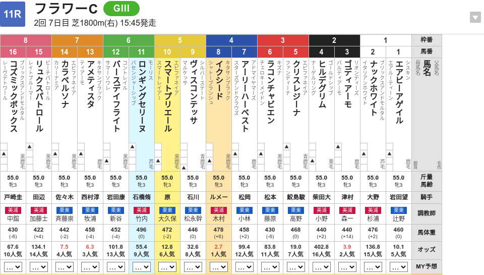

### 【ファルコンステークス 2026/03/21(土) 】

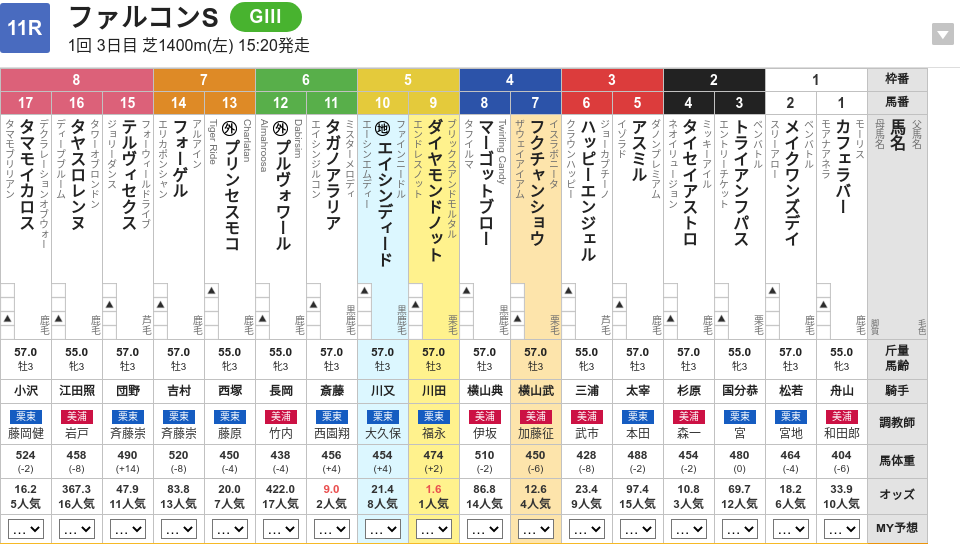

### 【阪神大賞典 2026/03/22(日) 】

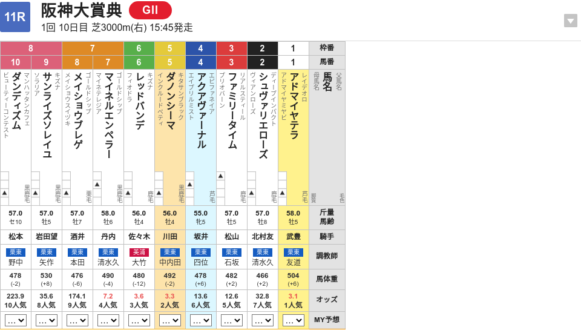

### 【愛知杯 2026/03/22(日) 】

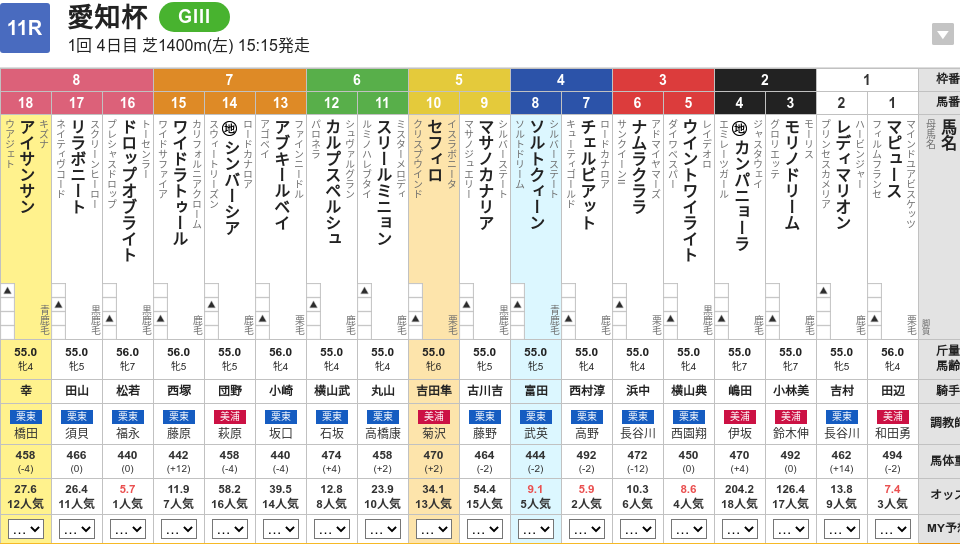

## 4. 単勝予測結果

### 【フラワーカップ(GⅢ) 2026/03/21(土)】

| 枠番 | 馬番 | 人気 | オッズ | 馬名 | 騎手 | 調教師 | 予測タイム(sec) | 1_順位 | 1-3着内確率(%) | 2_順位 | ﾀﾞｰｸﾎｰｽ確率(%) | 3_順位 |
| --- | --- | --- | --- | --- | --- | --- | --- | --- | --- | --- | --- | --- |
| 1 | 1 | 5 | 10.1 | エアビーアゲイル | 岩田望来 | 辻野泰之 | 113.9 | 9 | 14.9 | 7 | 0.7 | 12 |
| 1 | 2 | 15 | 136.8 | ナックホワイト | 大野拓弥 | 杉浦宏昭 | 118.4 | 13 | 3.3 | 16 | 12.3 | 7 |
| 2 | 3 | 2 | 3.9 | ゴディアーモ | 津村明秀 | 森一誠 | 111.3 | 6 | 55.7 | 1 | 0.4 | 15 |
| 2 | 4 | 16 | 402.8 | ヒルデグリム | 柴田大知 | 小野次郎 | 111.0 | 2 | 14.7 | 8 | 50.9 | 1 |
| 3 | 5 | 7 | 19.0 | クリスレジーナ | 鮫島克駿 | 高野友和 | 111.5 | 7 | 33.7 | 3 | 1.3 | 9 |
| 3 | 6 | 11 | 83.8 | ラコンチャビエン | 松本大輝 | 藤原英昭 | 118.5 | 14 | 3.3 | 15 | 11.9 | 8 |
| 4 | 7 | 12 | 99.4 | アーリーハーベスト | 松岡正海 | 小林真也 | 114.5 | 10 | 9.6 | 11 | 43.4 | 2 |
| 4 | 8 | 1 | 2.7 | イクシード | Ｃ．ルメール | 木村哲也 | 107.0 | 1 | 33.1 | 4 | 0.4 | 14 |
| 5 | 9 | 8 | 32.6 | ヴィスコンテッサ | 石川裕紀人 | 松永幹夫 | 119.2 | 15 | 7.6 | 12 | 1.0 | 10 |
| 5 | 10 | 6 | 12.8 | スマートプリエール | 原優介 | 大久保龍志 | 111.7 | 8 | 24.1 | 6 | 1.0 | 11 |

[output cut: 6 more lines]

### 【ファルコンステークス(GⅢ) 2026/03/21(土)】

| 枠番 | 馬番 | 人気 | オッズ | 馬名 | 騎手 | 調教師 | 予測タイム(sec) | 1_順位 | 1-3着内確率(%) | 2_順位 | ﾀﾞｰｸﾎｰｽ確率(%) | 3_順位 |
| --- | --- | --- | --- | --- | --- | --- | --- | --- | --- | --- | --- | --- |
| 1 | 1 | 10 | 33.9 | カフェラバー | 舟山瑠泉 | 和田正一郎 | 81.7 | 9 | 15.9 | 7 | 31.3 | 3.0 |
| 1 | 2 | 6 | 18.2 | メイクワンズデイ | 松若風馬 | 宮地貴稔 | 89.7 | 16 | 13.5 | 9 | 0.7 | 15.0 |
| 2 | 3 | 12 | 69.7 | トライアンフパス | 国分恭介 | 宮徹 | 89.2 | 13 | 6.2 | 14 | 12.8 | 5.0 |
| 2 | 4 | 3 | 10.8 | タイセイアストロ | 杉原誠人 | 森一誠 | 90.4 | 17 | 14.2 | 8 | 0.8 | 14.0 |
| 3 | 5 | 15 | 97.4 | アスミル | 太宰啓介 | 本田優 | 79.5 | 3 | 8.8 | 11 | 47.3 | 1.0 |
| 3 | 6 | 9 | 23.4 | ハッピーエンジェル | 三浦皇成 | 武市康男 | 79.1 | 2 | 16.5 | 6 | 1.1 | 9.0 |
| 4 | 7 | 4 | 12.6 | フクチャンショウ | 横山武史 | 加藤征弘 | 79.8 | 6 | 28.7 | 2 | 0.9 | 13.0 |
| 4 | 8 | 14 | 86.8 | マーゴットブロー | 横山典弘 | 伊坂重信 | 79.5 | 4 | 8.4 | 12 | 44.4 | 2.0 |
| 5 | 9 | 1 | 1.6 | ダイヤモンドノット | 川田将雅 | 福永祐一 | 68.7 | 1 | 18.3 | 4 | 0.4 | 16.5 |
| 5 | 10 | 8 | 21.4 | エイシンディード | 川又賢治 | 大久保龍志 | 79.9 | 8 | 16.5 | 5 | 1.0 | 11.0 |

[output cut: 7 more lines]

### 【阪神大賞典(GⅡ) 2026/03/22(日)】

| 枠番 | 馬番 | 人気 | オッズ | 馬名 | 騎手 | 調教師 | 予測タイム(sec) | 1_順位 | 1-3着内確率(%) | 2_順位 | ﾀﾞｰｸﾎｰｽ確率(%) | 3_順位 |
| --- | --- | --- | --- | --- | --- | --- | --- | --- | --- | --- | --- | --- |
| 1 | 1 | 1 | 3.1 | アドマイヤテラ | 武豊 | 友道康夫 | 182.6 | 1.5 | 19.7 | 5 | 0.4 | 8 |
| 2 | 2 | 7 | 32.8 | シュヴァリエローズ | 北村友一 | 清水久詞 | 195.1 | 5.0 | 10.0 | 7 | 26.2 | 2 |
| 3 | 3 | 5 | 12.6 | ファミリータイム | 松山弘平 | 石坂公一 | 201.0 | 6.0 | 24.2 | 4 | 0.9 | 6 |
| 4 | 4 | 6 | 13.6 | アクアヴァーナル | 坂井瑠星 | 四位洋文 | 201.5 | 8.0 | 13.1 | 6 | 13.5 | 5 |
| 5 | 5 | 2 | 3.3 | ダノンシーマ | 川田将雅 | 中内田充正 | 188.9 | 3.0 | 26.6 | 1 | 0.5 | 7 |
| 6 | 6 | 3 | 3.6 | レッドバンデ | 佐々木大輔 | 大竹正博 | 182.6 | 1.5 | 24.6 | 3 | 0.4 | 9 |
| 7 | 7 | 4 | 7.2 | マイネルエンペラー | 丹内祐次 | 清水久詞 | 193.1 | 4.0 | 25.0 | 2 | 0.4 | 10 |
| 7 | 8 | 9 | 174.1 | メイショウブレゲ | 酒井学 | 本田優 | 201.6 | 9.0 | 2.1 | 10 | 13.7 | 4 |
| 8 | 9 | 8 | 35.6 | サンライズソレイユ | 岩田望来 | 矢作芳人 | 201.5 | 7.0 | 4.8 | 8 | 36.1 | 1 |
| 8 | 10 | 10 | 223.9 | ダンディズム | 松本大輝 | 野中賢二 | 202.6 | 10.0 | 2.1 | 9 | 16.7 | 3 |

### 【愛知杯(GⅢ) 2026/03/22(日)】

| 枠番 | 馬番 | 人気 | オッズ | 馬名 | 騎手 | 調教師 | 予測タイム(sec) | 1_順位 | 1-3着内確率(%) | 2_順位 | ﾀﾞｰｸﾎｰｽ確率(%) | 3_順位 |
| --- | --- | --- | --- | --- | --- | --- | --- | --- | --- | --- | --- | --- |
| 1 | 1 | 3 | 7.4 | マピュース | 田辺裕信 | 和田勇介 | 123.4 | 4.0 | 44.6 | 2 | 0.4 | 16.0 |
| 1 | 2 | 9 | 13.8 | レディマリオン | 吉村誠之助 | 長谷川浩大 | 126.3 | 14.0 | 18.4 | 8 | 1.0 | 10.0 |
| 2 | 3 | 17 | 126.4 | モリノドリーム | 小林美駒 | 鈴木伸尋 | 131.0 | 16.0 | 2.1 | 17 | 13.7 | 6.0 |
| 2 | 4 | 18 | 204.2 | カンパニョーラ | 嶋田純次 | 伊坂重信 | 130.9 | 15.0 | 3.1 | 15 | 11.7 | 8.0 |
| 3 | 5 | 4 | 8.6 | ウイントワイライト | 横山典弘 | 西園翔太 | 123.9 | 9.0 | 41.9 | 3 | 0.4 | 13.0 |
| 3 | 6 | 6 | 10.3 | ナムラクララ | 浜中俊 | 長谷川浩大 | 124.2 | 11.0 | 27.2 | 5 | 0.7 | 12.0 |
| 4 | 7 | 2 | 5.9 | チェルビアット | 西村淳也 | 高野友和 | 124.9 | 13.0 | 55.2 | 1 | 0.4 | 14.5 |
| 4 | 8 | 5 | 9.1 | ソルトクィーン | 富田暁 | 武英智 | 123.7 | 8.0 | 37.8 | 4 | 0.4 | 14.5 |
| 5 | 9 | 15 | 54.4 | マサノカナリア | 古川吉洋 | 藤野健太 | 123.6 | 6.5 | 10.8 | 12 | 44.2 | 1.0 |
| 5 | 10 | 13 | 34.1 | セフィロ | 吉田隼人 | 菊沢隆徳 | 123.6 | 6.5 | 11.0 | 11 | 40.4 | 2.0 |

[output cut: 7 more lines]

## 5. 人気と着順の乖離率推移

### 【フラワーカップ_1990y_2019y】

[interactive chart not shown]

### 【ファルコンステークス_2001y_2019y】

[interactive chart not shown]

### 【阪神大賞典_1990y_2019y】

[interactive chart not shown]

### 【愛知杯_1990y_2019y】

[interactive chart not shown]

### 【フラワーカップ_1990y_2019y】

| No | 開催年 | 不整合率(%) | 頭数 | 人気別着順(1-3位) | 人気別着順(全体) |
| --- | --- | --- | --- | --- | --- |
| 30 | 2019 | 24.8 | 13頭 | 2-1-5 | 2\|1\|5\|3\|8\|10\|13\|6\|4\|12\|7\|9\|11 |
| 29 | 2018 | 42.6 | 13頭 | 2-3-4 | 2\|3\|4\|8\|9\|5\|6\|7\|12\|10\|11\|13\|1 |
| 28 | 2017 | 41.8 | 13頭 | 1-8-7 | 1\|8\|7\|12\|4\|3\|5\|10\|6\|11\|2\|9\|13 |
| 27 | 2016 | 16.9 | 16頭 | 1-2-14 | 1\|2\|14\|4\|13\|7\|5\|3\|11\|8\|6\|10\|15\|12\|9\|16 |
| 26 | 2015 | 16.0 | 16頭 | 1-12-2 | 1\|12\|2\|4\|3\|7\|10\|15\|14\|8\|13\|5\|16\|11\|9\|6 |
| 25 | 2014 | 44.8 | 16頭 | 3-4-6 | 3\|4\|6\|10\|1\|11\|2\|7\|8\|5\|12\|15\|9\|13\|16\|14 |
| 24 | 2013 | 40.4 | 14頭 | 2-3-6 | 2\|3\|6\|12\|5\|9\|1\|4\|11\|14\|10\|7\|8\|13 |
| 23 | 2012 | 25.3 | 16頭 | 6-1-10 | 6\|1\|10\|2\|4\|7\|11\|12\|5\|3\|16\|9\|14\|8\|13\|15 |
| 22 | 2011 | 29.6 | 18頭 | 5-1-7 | 5\|1\|7\|2\|12\|8\|4\|6\|10\|17\|18\|11\|13\|9\|15\|14\|3\|16 |
| 21 | 2010 | 38.8 | 16頭 | 3-4-1 | 3\|4\|1\|6\|2\|10\|5\|8\|7\|12\|9\|11\|14\|16\|15\|13 |

[output cut: 20 more lines]

### 【ファルコンステークス_2001y_2019y】

| No | 開催年 | 不整合率(%) | 頭数 | 人気別着順(1-3位) | 人気別着順(全体) |
| --- | --- | --- | --- | --- | --- |
| 19 | 2019 | 59.6 | 15頭 | 4-3-2 | 4\|3\|2\|11\|14\|1\|7\|13\|12\|10\|5\|8\|9\|6\|15 |
| 18 | 2018 | 54.5 | 16頭 | 3-7-5 | 3\|7\|5\|4\|9\|6\|1\|2\|12\|13\|10\|11\|14\|16\|8\|15 |
| 17 | 2017 | 54.9 | 16頭 | 3-2-6 | 3\|2\|6\|12\|10\|4\|8\|14\|9\|7\|1\|5\|11\|13\|15\|16 |
| 16 | 2016 | 48.6 | 18頭 | 2-3-9 | 2\|3\|9\|8\|15\|13\|7\|5\|18\|10\|4\|1\|12\|14\|16\|11\|6\|17 |
| 15 | 2015 | 46.6 | 18頭 | 14-4-5 | 14\|4\|5\|1\|12\|8\|7\|3\|9\|16\|13\|2\|11\|6\|17\|10\|15\|18 |
| 14 | 2014 | 25.3 | 18頭 | 1-3-11 | 1\|3\|11\|7\|5\|2\|4\|6\|10\|15\|8\|17\|9\|14\|16\|13\|12\|18 |
| 13 | 2013 | 41.3 | 18頭 | 2-11-5 | 2\|11\|5\|4\|10\|9\|1\|7\|6\|3\|8\|12\|15\|16\|17\|13\|18\|14 |
| 12 | 2012 | 46.9 | 18頭 | 4-12-3 | 4\|12\|3\|1\|5\|13\|18\|6\|7\|2\|8\|14\|16\|11\|15\|17\|10\|9 |
| 11 | 2011 | 54.8 | 14頭 | 9-4-2 | 9\|4\|2\|6\|3\|10\|11\|14\|13\|1\|12\|7\|5\|8 |
| 10 | 2010 | 58.3 | 18頭 | 4-10-5 | 4\|10\|5\|2\|17\|11\|6\|15\|3\|8\|12\|14\|13\|7\|1\|9\|16\|18 |

[output cut: 9 more lines]

### 【阪神大賞典_1990y_2019y】

| No | 開催年 | 不整合率(%) | 頭数 | 人気別着順(1-3位) | 人気別着順(全体) |
| --- | --- | --- | --- | --- | --- |
| 30 | 2019 | 30.9 | 11頭 | 1-6-10 | 1\|6\|10\|9\|4\|2\|8\|5\|7\|3\|11 |
| 29 | 2018 | 42.9 | 11頭 | 3-4-1 | 3\|4\|1\|2\|6\|7\|10\|5\|9\|8\|11 |
| 28 | 2017 | 14.0 | 10頭 | 1-2-5 | 1\|2\|5\|6\|8\|9\|3\|10\|4\|7 |
| 27 | 2016 | 33.9 | 11頭 | 1-4-3 | 1\|4\|3\|9\|8\|5\|2\|6\|7\|11\|10 |
| 26 | 2015 | 14.4 | 10頭 | 1-7-2 | 1\|7\|2\|6\|8\|3\|9\|4\|5\|10 |
| 25 | 2014 | 26.7 | 9頭 | 1-5-3 | 1\|5\|3\|2\|4\|7\|9\|6\|8 |
| 24 | 2013 | 23.6 | 9頭 | 1-3-5 | 1\|3\|5\|2\|4\|9\|8\|6\|7 |
| 23 | 2012 | 37.0 | 11頭 | 3-1-5 | 3\|1\|5\|2\|4\|8\|10\|7\|9\|6\|12 |
| 22 | 2011 | 42.2 | 13頭 | 3-1-6 | 3\|1\|6\|7\|11\|5\|12\|2\|4\|8\|10\|9\|13 |
| 21 | 2010 | 47.2 | 14頭 | 5-4-1 | 5\|4\|1\|6\|3\|13\|8\|14\|2\|7\|11\|10\|12\|9 |

[output cut: 20 more lines]

### 【愛知杯_1990y_2019y】

| No | 開催年 | 不整合率(%) | 頭数 | 人気別着順(1-3位) | 人気別着順(全体) |
| --- | --- | --- | --- | --- | --- |
| 29 | 2019 | 33.8 | 14頭 | 8-1-4 | 8\|1\|4\|3\|6\|2\|7\|5\|10\|9\|13\|11\|14\|12 |
| 28 | 2018 | 41.2 | 17頭 | 6-11-1 | 6\|11\|1\|3\|5\|16\|8\|15\|12\|4\|7\|10\|17\|14\|18\|9\|2 |
| 27 | 2017 | 31.1 | 15頭 | 1-10-6 | 1\|10\|6\|15\|8\|14\|3\|12\|2\|13\|9\|4\|5\|11\|7 |
| 26 | 2016 | 51.7 | 18頭 | 8-5-4 | 8\|5\|4\|2\|12\|10\|15\|1\|13\|16\|7\|18\|3\|14\|11\|9\|6\|17 |
| 25 | 2014 | 16.6 | 18頭 | 1-2-10 | 1\|2\|10\|4\|14\|3\|12\|6\|11\|8\|7\|18\|5\|9\|13\|15\|16\|17 |
| 24 | 2013 | 52.1 | 18頭 | 12-14-13 | 12\|14\|13\|8\|11\|1\|5\|15\|6\|4\|7\|17\|3\|2\|9\|16\|10\|18 |
| 23 | 2012 | 39.8 | 18頭 | 7-10-2 | 7\|10\|2\|8\|3\|1\|4\|9\|16\|6\|13\|5\|12\|14\|17\|11\|18\|15 |
| 22 | 2011 | 37.6 | 16頭 | 2-9-3 | 2\|9\|3\|1\|8\|7\|11\|13\|14\|4\|6\|5\|16\|12\|10\|15 |
| 21 | 2010 | 20.3 | 17頭 | 6-1-2 | 6\|1\|2\|3\|7\|8\|16\|15\|14\|13\|9\|11\|12\|17\|18\|5\|10 |
| 20 | 2009 | 39.0 | 18頭 | 4-7-1 | 4\|7\|1\|3\|5\|6\|9\|16\|8\|15\|2\|11\|14\|10\|18\|12\|17\|13 |

[output cut: 19 more lines]

## 6. 1-3番人気馬の着順分類予測

### 【フラワーカップ】

| 分類 | 凡例 | 発生確率(%) | 当該レース | 当該レースランク | 直近1年間 |
| --- | --- | --- | --- | --- | --- |
| 4: 1,2番人気のみ (4_pop12) | 1 \| 2 \| * | 18.4 | 0.39 | 0.74 | 0.74 |
| 1: 1番人気のみ (1_pop1) | 1 \| * \| * | 17.9 | 0.81 | 0.72 | 0.36 |
| 8: 1,2,3番人気すべて着外 (8_darkhorse) | * \| * \| * | 14.2 | 5.07 | 1.51 | 0.00 |
| 5: 1,3番人気のみ (5_pop13) | 1 \| 3 \| * | 12.7 | 1.53 | 3.02 | 0.00 |
| 2: 2番人気のみ (2_pop2) | 2 \| * \| * | 10.7 | 3.82 | 1.47 | 0.00 |
| 6: 2,3番人気のみ (6_pop23) | 2 \| 3 \| * | 10.1 | 1.80 | 0.60 | 0.40 |
| 3: 3番人気のみ (3_pop3) | 3 \| * \| * | 8.9 | 1.07 | 0.95 | 0.00 |
| 7: 1,2,3番人気すべて着内 (7_pop123) | 1 \| 2 \| 3 | 7.1 | 2.54 | 2.29 | 0.00 |

### 【ファルコンステークス】

| 分類 | 凡例 | 発生確率(%) | 当該レース | 当該レースランク | 直近1年間 |
| --- | --- | --- | --- | --- | --- |
| 4: 1,2番人気のみ (4_pop12) | 1 \| 2 \| * | 18.0 | 2.25 | 0.72 | 0.72 |
| 1: 1番人気のみ (1_pop1) | 1 \| * \| * | 17.2 | 2.15 | 0.69 | 0.34 |
| 8: 1,2,3番人気すべて着外 (8_darkhorse) | * \| * \| * | 14.1 | 1.17 | 1.50 | 0.00 |
| 5: 1,3番人気のみ (5_pop13) | 1 \| 3 \| * | 12.7 | 3.17 | 3.02 | 0.00 |
| 6: 2,3番人気のみ (6_pop23) | 2 \| 3 \| * | 11.7 | 0.27 | 0.70 | 0.47 |
| 2: 2番人気のみ (2_pop2) | 2 \| * \| * | 10.2 | 0.85 | 1.40 | 0.00 |
| 3: 3番人気のみ (3_pop3) | 3 \| * \| * | 8.9 | 0.74 | 0.95 | 0.00 |
| 7: 1,2,3番人気すべて着内 (7_pop123) | 1 \| 2 \| 3 | 7.1 | 0.00 | 2.29 | 0.00 |

### 【阪神大賞典】

| 分類 | 凡例 | 発生確率(%) | 当該レース | 当該レースランク | 直近1年間 |
| --- | --- | --- | --- | --- | --- |
| 4: 1,2番人気のみ (4_pop12) | 1 \| 2 \| * | 18.4 | 0.83 | 0.83 | 0.00 |
| 1: 1番人気のみ (1_pop1) | 1 \| * \| * | 17.9 | 0.58 | 0.58 | 0.18 |
| 8: 1,2,3番人気すべて着外 (8_darkhorse) | * \| * \| * | 14.2 | 0.00 | 0.00 | 0.00 |
| 5: 1,3番人気のみ (5_pop13) | 1 \| 3 \| * | 12.7 | 0.57 | 0.57 | 0.00 |
| 2: 2番人気のみ (2_pop2) | 2 \| * \| * | 10.7 | 3.82 | 3.82 | 0.00 |
| 6: 2,3番人気のみ (6_pop23) | 2 \| 3 \| * | 10.1 | 0.00 | 0.00 | 0.00 |
| 3: 3番人気のみ (3_pop3) | 3 \| * \| * | 8.9 | 0.00 | 0.00 | 0.00 |
| 7: 1,2,3番人気すべて着内 (7_pop123) | 1 \| 2 \| 3 | 7.1 | 0.32 | 0.32 | 0.00 |

### 【愛知杯】

| 分類 | 凡例 | 発生確率(%) | 当該レース | 当該レースランク | 直近1年間 |
| --- | --- | --- | --- | --- | --- |
| 4: 1,2番人気のみ (4_pop12) | 1 \| 2 \| * | 18.0 | 1.26 | 1.26 | 0.00 |
| 1: 1番人気のみ (1_pop1) | 1 \| * \| * | 17.2 | 0.43 | 0.43 | 0.17 |
| 8: 1,2,3番人気すべて着外 (8_darkhorse) | * \| * \| * | 14.1 | 0.99 | 0.99 | 0.00 |
| 5: 1,3番人気のみ (5_pop13) | 1 \| 3 \| * | 12.7 | 0.00 | 0.00 | 0.00 |
| 6: 2,3番人気のみ (6_pop23) | 2 \| 3 \| * | 11.7 | 1.36 | 1.36 | 0.00 |
| 2: 2番人気のみ (2_pop2) | 2 \| * \| * | 10.2 | 1.19 | 1.19 | 0.00 |
| 3: 3番人気のみ (3_pop3) | 3 \| * \| * | 8.9 | 1.03 | 1.03 | 0.00 |
| 7: 1,2,3番人気すべて着内 (7_pop123) | 1 \| 2 \| 3 | 7.1 | 1.25 | 1.25 | 0.00 |

## 7. 3連複予測結果

### 【フラワーカップ(GⅢ) 2026/03/21(土)】

| 分類 | 馬番 | 枠番 | 人気 | 平均予測タイム(sec) | 1-3着内確率(%) | ﾀﾞｰｸﾎｰｽ確率(%) | 馬名 | 騎手 | 調教師 |
| --- | --- | --- | --- | --- | --- | --- | --- | --- | --- |
| 2: 2番人気のみ (2_pop2) | 3-14-5 | 2-7-3 | 2-4-7 | 111.33 | 6.85 | 0.00 | ゴディアーモ \| カラペルソナ \| クリスレジーナ | 津村明秀 \| 佐々木大輔 \| 鮫島克駿 | 森一誠 \| 斉藤崇史 \| 高野友和 |
| 4: 1,2番人気のみ (4_pop12) | 8-3-14 | 4-2-7 | 1-2-4 | 109.83 | 6.73 | 0.00 | イクシード \| ゴディアーモ \| カラペルソナ | Ｃ．ルメール \| 津村明秀 \| 佐々木大輔 | 木村哲也 \| 森一誠 \| 斉藤崇史 |
| 4: 1,2番人気のみ (4_pop12) | 8-3-5 | 4-2-3 | 1-2-7 | 109.93 | 6.22 | 0.00 | イクシード \| ゴディアーモ \| クリスレジーナ | Ｃ．ルメール \| 津村明秀 \| 鮫島克駿 | 木村哲也 \| 森一誠 \| 高野友和 |
| 6: 2,3番人気のみ (6_pop23) | 3-13-14 | 2-7-7 | 2-3-4 | 112.33 | 5.73 | 0.00 | ゴディアーモ \| アメティスタ \| カラペルソナ | 津村明秀 \| 西村淳也 \| 佐々木大輔 | 森一誠 \| 牧浦充徳 \| 斉藤崇史 |
| 6: 2,3番人気のみ (6_pop23) | 3-13-5 | 2-7-3 | 2-3-7 | 112.43 | 5.30 | 0.00 | ゴディアーモ \| アメティスタ \| クリスレジーナ | 津村明秀 \| 西村淳也 \| 鮫島克駿 | 森一誠 \| 牧浦充徳 \| 高野友和 |
| 7: 1,2,3番人気すべて着内 (7_pop123) | 8-3-13 | 4-2-7 | 1-2-3 | 110.93 | 5.21 | 0.00 | イクシード \| ゴディアーモ \| アメティスタ | Ｃ．ルメール \| 津村明秀 \| 西村淳也 | 木村哲也 \| 森一誠 \| 牧浦充徳 |
| 2: 2番人気のみ (2_pop2) | 3-14-10 | 2-7-5 | 2-4-6 | 111.40 | 4.88 | 0.00 | ゴディアーモ \| カラペルソナ \| スマートプリエール | 津村明秀 \| 佐々木大輔 \| 原優介 | 森一誠 \| 斉藤崇史 \| 大久保龍志 |
| 2: 2番人気のみ (2_pop2) | 3-10-5 | 2-5-3 | 2-6-7 | 111.50 | 4.52 | 0.00 | ゴディアーモ \| スマートプリエール \| クリスレジーナ | 津村明秀 \| 原優介 \| 鮫島克駿 | 森一誠 \| 大久保龍志 \| 高野友和 |
| 4: 1,2番人気のみ (4_pop12) | 8-3-10 | 4-2-5 | 1-2-6 | 110.00 | 4.44 | 0.00 | イクシード \| ゴディアーモ \| スマートプリエール | Ｃ．ルメール \| 津村明秀 \| 原優介 | 木村哲也 \| 森一誠 \| 大久保龍志 |
| 1: 1番人気のみ (1_pop1) | 8-14-5 | 4-7-3 | 1-4-7 | 109.90 | 4.07 | 0.00 | イクシード \| カラペルソナ \| クリスレジーナ | Ｃ．ルメール \| 佐々木大輔 \| 鮫島克駿 | 木村哲也 \| 斉藤崇史 \| 高野友和 |

[output cut: 550 more lines]

### 【ファルコンステークス(GⅢ) 2026/03/21(土)】

| 分類 | 馬番 | 枠番 | 人気 | 平均予測タイム(sec) | 1-3着内確率(%) | ﾀﾞｰｸﾎｰｽ確率(%) | 馬名 | 騎手 | 調教師 |
| --- | --- | --- | --- | --- | --- | --- | --- | --- | --- |
| 2: 2番人気のみ (2_pop2) | 11-7-17 | 6-4-8 | 2-4-5 | 79.80 | 2.57 | 0.00 | タガノアラリア \| フクチャンショウ \| タマモイカロス | 斎藤新 \| 横山武史 \| 小沢大仁 | 西園翔太 \| 加藤征弘 \| 藤岡健一 |
| 4: 1,2番人気のみ (4_pop12) | 9-11-7 | 5-6-4 | 1-2-4 | 76.10 | 2.05 | 0.00 | ダイヤモンドノット \| タガノアラリア \| フクチャンショウ | 川田将雅 \| 斎藤新 \| 横山武史 | 福永祐一 \| 西園翔太 \| 加藤征弘 |
| 2: 2番人気のみ (2_pop2) | 11-7-10 | 6-4-5 | 2-4-8 | 79.83 | 1.85 | 0.00 | タガノアラリア \| フクチャンショウ \| エイシンディード | 斎藤新 \| 横山武史 \| 川又賢治 | 西園翔太 \| 加藤征弘 \| 大久保龍志 |
| 2: 2番人気のみ (2_pop2) | 11-7-6 | 6-4-3 | 2-4-9 | 79.57 | 1.85 | 0.00 | タガノアラリア \| フクチャンショウ \| ハッピーエンジェル | 斎藤新 \| 横山武史 \| 三浦皇成 | 西園翔太 \| 加藤征弘 \| 武市康男 |
| 2: 2番人気のみ (2_pop2) | 11-7-1 | 6-4-1 | 2-4-10 | 80.43 | 1.78 | 0.00 | タガノアラリア \| フクチャンショウ \| カフェラバー | 斎藤新 \| 横山武史 \| 舟山瑠泉 | 西園翔太 \| 加藤征弘 \| 和田正一郎 |
| 4: 1,2番人気のみ (4_pop12) | 9-11-17 | 5-6-8 | 1-2-5 | 76.10 | 1.64 | 0.00 | ダイヤモンドノット \| タガノアラリア \| タマモイカロス | 川田将雅 \| 斎藤新 \| 小沢大仁 | 福永祐一 \| 西園翔太 \| 藤岡健一 |
| 6: 2,3番人気のみ (6_pop23) | 11-4-7 | 6-2-4 | 2-3-4 | 83.33 | 1.59 | 0.00 | タガノアラリア \| タイセイアストロ \| フクチャンショウ | 斎藤新 \| 杉原誠人 \| 横山武史 | 西園翔太 \| 森一誠 \| 加藤征弘 |
| 2: 2番人気のみ (2_pop2) | 11-7-2 | 6-4-1 | 2-4-6 | 83.10 | 1.51 | 0.00 | タガノアラリア \| フクチャンショウ \| メイクワンズデイ | 斎藤新 \| 横山武史 \| 松若風馬 | 西園翔太 \| 加藤征弘 \| 宮地貴稔 |
| 2: 2番人気のみ (2_pop2) | 11-17-10 | 6-8-5 | 2-5-8 | 79.83 | 1.48 | 0.00 | タガノアラリア \| タマモイカロス \| エイシンディード | 斎藤新 \| 小沢大仁 \| 川又賢治 | 西園翔太 \| 藤岡健一 \| 大久保龍志 |
| 2: 2番人気のみ (2_pop2) | 11-17-6 | 6-8-3 | 2-5-9 | 79.57 | 1.48 | 0.00 | タガノアラリア \| タマモイカロス \| ハッピーエンジェル | 斎藤新 \| 小沢大仁 \| 三浦皇成 | 西園翔太 \| 藤岡健一 \| 武市康男 |

[output cut: 670 more lines]

### 【阪神大賞典(GⅡ) 2026/03/22(日)】

| 分類 | 馬番 | 枠番 | 人気 | 平均予測タイム(sec) | 1-3着内確率(%) | ﾀﾞｰｸﾎｰｽ確率(%) | 馬名 | 騎手 | 調教師 |
| --- | --- | --- | --- | --- | --- | --- | --- | --- | --- |
| 6: 2,3番人気のみ (6_pop23) | 5-6-7 | 5-6-7 | 2-3-4 | 188.20 | 1.63 | 0.00 | ダノンシーマ \| レッドバンデ \| マイネルエンペラー | 川田将雅 \| 佐々木大輔 \| 丹内祐次 | 中内田充正 \| 大竹正博 \| 清水久詞 |
| 2: 2番人気のみ (2_pop2) | 5-7-3 | 5-7-3 | 2-4-5 | 194.33 | 1.61 | 0.00 | ダノンシーマ \| マイネルエンペラー \| ファミリータイム | 川田将雅 \| 丹内祐次 \| 松山弘平 | 中内田充正 \| 清水久詞 \| 石坂公一 |
| 6: 2,3番人気のみ (6_pop23) | 5-6-3 | 5-6-3 | 2-3-5 | 190.83 | 1.58 | 0.00 | ダノンシーマ \| レッドバンデ \| ファミリータイム | 川田将雅 \| 佐々木大輔 \| 松山弘平 | 中内田充正 \| 大竹正博 \| 石坂公一 |
| 3: 3番人気のみ (3_pop3) | 6-7-3 | 6-7-3 | 3-4-5 | 192.23 | 1.48 | 0.00 | レッドバンデ \| マイネルエンペラー \| ファミリータイム | 佐々木大輔 \| 丹内祐次 \| 松山弘平 | 大竹正博 \| 清水久詞 \| 石坂公一 |
| 4: 1,2番人気のみ (4_pop12) | 1-5-7 | 1-5-7 | 1-2-4 | 188.20 | 1.31 | 0.00 | アドマイヤテラ \| ダノンシーマ \| マイネルエンペラー | 武豊 \| 川田将雅 \| 丹内祐次 | 友道康夫 \| 中内田充正 \| 清水久詞 |
| 7: 1,2,3番人気すべて着内 (7_pop123) | 1-5-6 | 1-5-6 | 1-2-3 | 184.70 | 1.28 | 0.00 | アドマイヤテラ \| ダノンシーマ \| レッドバンデ | 武豊 \| 川田将雅 \| 佐々木大輔 | 友道康夫 \| 中内田充正 \| 大竹正博 |
| 4: 1,2番人気のみ (4_pop12) | 1-5-3 | 1-5-3 | 1-2-5 | 190.83 | 1.26 | 0.00 | アドマイヤテラ \| ダノンシーマ \| ファミリータイム | 武豊 \| 川田将雅 \| 松山弘平 | 友道康夫 \| 中内田充正 \| 石坂公一 |
| 5: 1,3番人気のみ (5_pop13) | 1-6-7 | 1-6-7 | 1-3-4 | 186.10 | 1.21 | 0.00 | アドマイヤテラ \| レッドバンデ \| マイネルエンペラー | 武豊 \| 佐々木大輔 \| 丹内祐次 | 友道康夫 \| 大竹正博 \| 清水久詞 |
| 1: 1番人気のみ (1_pop1) | 1-7-3 | 1-7-3 | 1-4-5 | 192.23 | 1.19 | 0.00 | アドマイヤテラ \| マイネルエンペラー \| ファミリータイム | 武豊 \| 丹内祐次 \| 松山弘平 | 友道康夫 \| 清水久詞 \| 石坂公一 |
| 5: 1,3番人気のみ (5_pop13) | 1-6-3 | 1-6-3 | 1-3-5 | 188.73 | 1.17 | 0.00 | アドマイヤテラ \| レッドバンデ \| ファミリータイム | 武豊 \| 佐々木大輔 \| 松山弘平 | 友道康夫 \| 大竹正博 \| 石坂公一 |

[output cut: 110 more lines]

### 【愛知杯(GⅢ) 2026/03/22(日)】

| 分類 | 馬番 | 枠番 | 人気 | 平均予測タイム(sec) | 1-3着内確率(%) | ﾀﾞｰｸﾎｰｽ確率(%) | 馬名 | 騎手 | 調教師 |
| --- | --- | --- | --- | --- | --- | --- | --- | --- | --- |
| 6: 2,3番人気のみ (6_pop23) | 7-1-5 | 4-1-3 | 2-3-4 | 124.07 | 10.31 | 0.00 | チェルビアット \| マピュース \| ウイントワイライト | 西村淳也 \| 田辺裕信 \| 横山典弘 | 高野友和 \| 和田勇介 \| 西園翔太 |
| 6: 2,3番人気のみ (6_pop23) | 7-1-8 | 4-1-4 | 2-3-5 | 124.00 | 9.32 | 0.00 | チェルビアット \| マピュース \| ソルトクィーン | 西村淳也 \| 田辺裕信 \| 富田暁 | 高野友和 \| 和田勇介 \| 武英智 |
| 2: 2番人気のみ (2_pop2) | 7-5-8 | 4-3-4 | 2-4-5 | 124.17 | 8.75 | 0.00 | チェルビアット \| ウイントワイライト \| ソルトクィーン | 西村淳也 \| 横山典弘 \| 富田暁 | 高野友和 \| 西園翔太 \| 武英智 |
| 3: 3番人気のみ (3_pop3) | 1-5-8 | 1-3-4 | 3-4-5 | 123.67 | 7.06 | 0.00 | マピュース \| ウイントワイライト \| ソルトクィーン | 田辺裕信 \| 横山典弘 \| 富田暁 | 和田勇介 \| 西園翔太 \| 武英智 |
| 6: 2,3番人気のみ (6_pop23) | 7-1-6 | 4-1-3 | 2-3-6 | 124.17 | 6.69 | 0.00 | チェルビアット \| マピュース \| ナムラクララ | 西村淳也 \| 田辺裕信 \| 浜中俊 | 高野友和 \| 和田勇介 \| 長谷川浩大 |
| 2: 2番人気のみ (2_pop2) | 7-5-6 | 4-3-3 | 2-4-6 | 124.33 | 6.28 | 0.00 | チェルビアット \| ウイントワイライト \| ナムラクララ | 西村淳也 \| 横山典弘 \| 浜中俊 | 高野友和 \| 西園翔太 \| 長谷川浩大 |
| 2: 2番人気のみ (2_pop2) | 7-8-6 | 4-4-3 | 2-5-6 | 124.27 | 5.68 | 0.00 | チェルビアット \| ソルトクィーン \| ナムラクララ | 西村淳也 \| 富田暁 \| 浜中俊 | 高野友和 \| 武英智 \| 長谷川浩大 |
| 6: 2,3番人気のみ (6_pop23) | 7-1-12 | 4-1-6 | 2-3-8 | 124.27 | 5.58 | 0.00 | チェルビアット \| マピュース \| カルプスペルシュ | 西村淳也 \| 田辺裕信 \| 横山武史 | 高野友和 \| 和田勇介 \| 石坂公一 |
| 2: 2番人気のみ (2_pop2) | 7-5-12 | 4-3-6 | 2-4-8 | 124.43 | 5.24 | 0.00 | チェルビアット \| ウイントワイライト \| カルプスペルシュ | 西村淳也 \| 横山典弘 \| 横山武史 | 高野友和 \| 西園翔太 \| 石坂公一 |
| 6: 2,3番人気のみ (6_pop23) | 7-1-15 | 4-1-7 | 2-3-7 | 123.87 | 5.10 | 0.00 | チェルビアット \| マピュース \| ワイドラトゥール | 西村淳也 \| 田辺裕信 \| 西塚洸二 | 高野友和 \| 和田勇介 \| 藤原英昭 |

[output cut: 550 more lines]

## 8. 直近の全レース情報

[output not shown]

[output cut: 9 more lines]